# Customer Rating of Breakfast Cereals

Dolores Chu

11/13/2019

##### The dataset Cereals.csv includes nutritional information, store display, and consumer ratings for 77 breakfast cereals.

##### Data Preprocessing. Remove all cereals with missing values.

```r
data <- read.csv("Cereals.csv")
data <- na.omit(data)
```

##### a. Apply hierarchical clustering to the data using Euclidean distance to the normalized measurements. Use Agnes to compare the clustering from single linkage, complete linkage, average linkage, and Ward. Choose the best method.

First, normalize data

```r
data_norm <- cbind(data[, 1:3], scale(data[, -c(1:3)]))
```

Apply hierarchical clustering to the data using Euclidean distance to the normalized measurements.

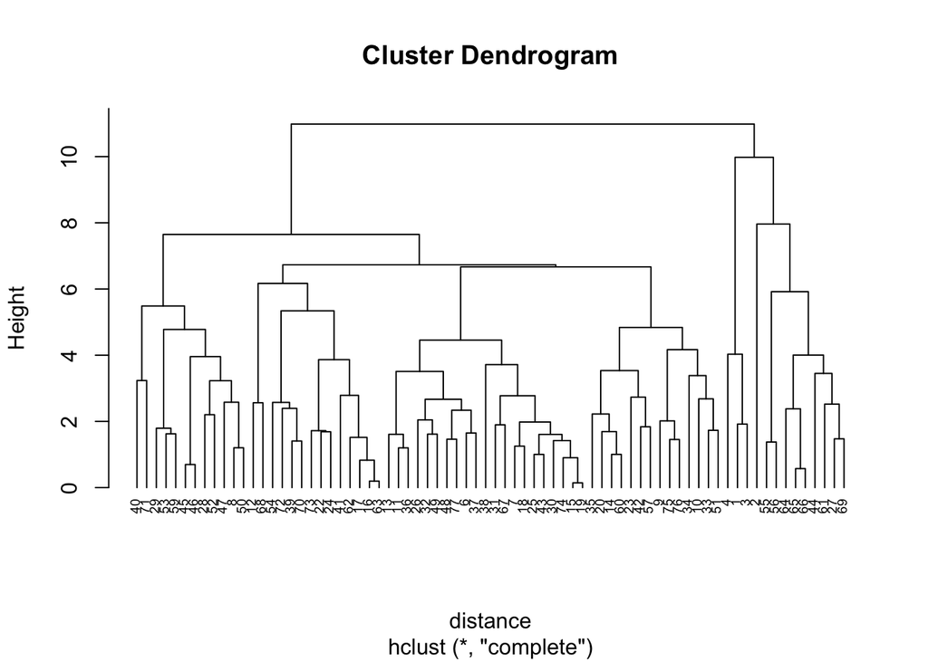

```r
distance <- dist(data_norm[, -c(1:3)], method = "euclidean")
hc1 <- hclust(distance, method = "complete")
plot(hc1, cex = 0.6, hang = -1)
```

Use Agnes to compare the clustering from single linkage, complete linkage, average linkage, and Ward. Choose the best method. The best method is Ward.

```r
library(cluster)
hc_single <- agnes(data_norm, method = "single")
hc_complete <- agnes(data_norm, method = "complete")
hc_average <- agnes(data_norm, method = "average")
hc_ward <- agnes(data_norm, method = "ward")
hc_single$ac
```

```
## [1] 0.5180212
```

```r
hc_complete$ac
```

```
## [1] 0.9479138
```

```r
hc_average$ac
```

```
## [1] 0.9007448
```

```r
hc_ward$ac
```

```
## [1] 0.981174
```

##### b. How many clusters would you choose?

I would start with choosing 6 clusters.

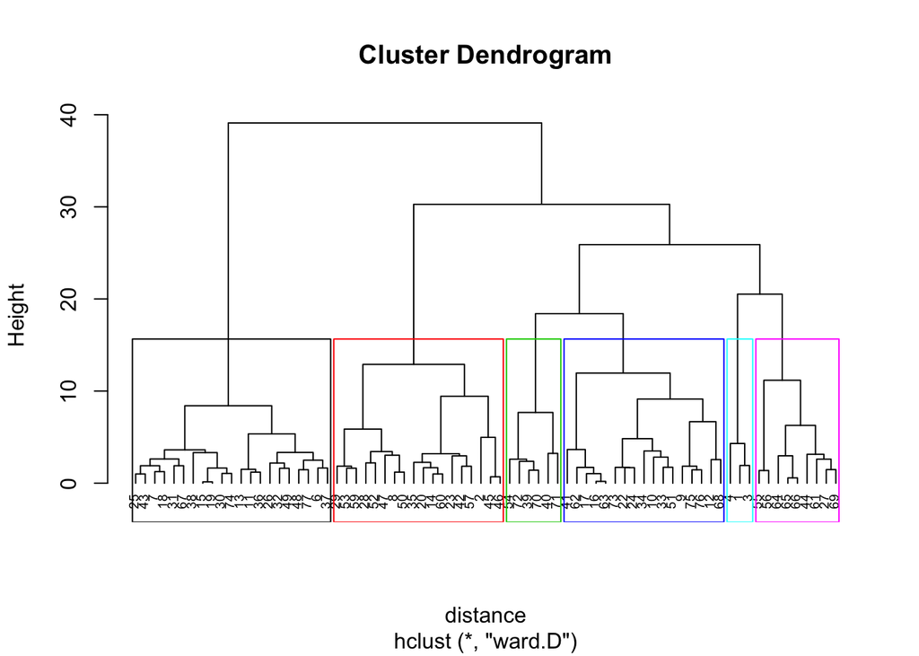

```r
hc_ward <- hclust(distance, method = "ward.D")
plot(hc_ward, cex = 0.6, hang = -1)
rect.hclust(hc_ward, k = 6, border = 1:6)
```

```r
Model_1 <- cutree(hc_ward, 6)
data <- cbind(data,Model_1)
```

##### c. Comment on the structure of the clusters and on their stability. Hint: To check stability, partition the data and see how well clusters formed based on one part apply to the other part. To do this:

##### a. Cluster partition A

```r
set.seed(123)
dataA_index <- sample(seq_len(nrow(data_norm)), size = 67)
dataA <- data_norm[dataA_index,]
dataB <- data_norm[-dataA_index,]
```

```r
dataA_dist <- dist(dataA[, -c(1:3)], method = "euclidean")
hc_A <- hclust(dataA_dist, method = "ward.D")
Model_A <- cutree(hc_A, 6)
dataA <- cbind(Model_A, dataA)
head(dataA)
```

```
##    Model_A                  name mfr type   calories    protein       fat
## 33       1     Grape_Nuts_Flakes   P    C -0.3541153  0.4522084 0.0000000
## 53       2 Post_Nat._Raisin_Bran   P    C  0.6537514  0.4522084 0.0000000
## 15       3           Cocoa_Puffs   G    C  0.1498180 -1.4068705 0.0000000
## 70       4     Total_Corn_Flakes   G    C  0.1498180 -0.4773310 0.0000000
## 44       5                 Maypo   A    H -0.3541153  1.3817478 0.0000000
## 52       2  Oatmeal_Raisin_Crisp   G    C  1.1576848  0.4522084 0.9932203
##         sodium      fiber       carbo     sugars      potass   vitamins
## 33 -0.27020566  0.3401532  0.06944832 -0.4836096 -0.19065695 -0.1818422
## 53  0.45469653  1.5780879 -0.95838683  1.5810314  2.27835060 -0.1818422
## 15  0.21306247 -0.8977815 -0.70142805  1.3516269 -0.61391539 -0.1818422
## 70  0.45469653 -0.8977815  1.61120105 -0.9424187 -0.89608768  3.1822385
## 44 -1.96164410 -0.8977815  0.32640711 -0.9424187 -0.04957081 -0.1818422
## 52  0.09224544 -0.2788141 -0.31598986  0.6634132  0.30314456 -0.1818422
##         shelf     weight       cups     rating
## 33  0.9419715 -0.2008324  0.2476647  0.6915569
## 53  0.9419715  1.9501886 -0.6432404 -0.3228791
## 15 -0.2598542 -0.2008324  0.7567534 -1.3991551
## 70  0.9419715 -0.2008324  0.7567534 -0.2516826
## 44 -0.2598542 -0.2008324  0.7567534  0.8892251
## 52  0.9419715  1.4287290 -1.3644493 -0.8494505
```

```r
library(dplyr)
C1 <- colMeans(dataA[dataA$Model_A == 1,5:ncol(dataA)])
C2 <- colMeans(dataA[dataA$Model_A == 2,5:ncol(dataA)])
C3 <- colMeans(dataA[dataA$Model_A == 3,5:ncol(dataA)])
C4 <- colMeans(dataA[dataA$Model_A == 4,5:ncol(dataA)])
C5 <- colMeans(dataA[dataA$Model_A == 5,5:ncol(dataA)])
C6 <- colMeans(dataA[dataA$Model_A == 6,5:ncol(dataA)])
Centroids_A <- rbind(C1, C2, C3, C4, C5, C6)
dist <- dist(rbind(Centroids_A,dataB[,4:ncol(dataB)]))
dist
```

```
##          C1       C2       C3       C4       C5       C6        3        4
## C2 3.087519
## C3 3.171116 3.766283
## C4 4.080860 4.394851 4.465807
## C5 3.120031 5.017983 4.225386 5.574752
## C6 3.992549 5.064938 3.600257 4.537638 4.243322
## 3  5.001063 6.043032 7.197863 7.486394 6.477277 7.838851
## 4  7.300259 8.670076 9.647012 9.528843 7.407964 9.662959 4.031051
## 35 2.937467 3.483268 4.492378 5.395800 4.485411 5.823893 5.940473 8.282237
## 42 2.116481 3.253686 3.177192 4.677708 3.523530 4.044877 5.449421 7.913299
## 55 5.871507 8.431790 6.391470 8.139591 4.910302 6.737769 8.695724 9.343676
## 56 5.617653 8.188194 6.445799 8.129250 4.710236 6.816139 7.916319 8.492807
## 76 3.013139 4.262622 3.278687 4.537729 3.020609 2.070710 6.290066 8.004134
##          35       42       55       56
## C2
## C3
## C4
## C5
## C6
## 3
## 4
## 35
## 42 2.768632
## 55 7.106645 6.462448
## 56 6.861611 6.052896 1.377717
## 76 4.732649 2.856300 6.290658 6.120699
```

##### c. Assess how consistent the cluster assignments are compared to the assignments based on all the data.

```r
Assignments<- data.frame(data[-dataA_index, "Model_1"])
Assignments$Model_A <- 0
Assignments[1,2] <- which.max(c(2.462441,3.146983,3.782227,5.983747,4.881300,3.826735))
Assignments[2,2] <- which.max(c(2.312626,3.855177, 4.581339, 8.455727 ,4.827885 ,5.441721))
Assignments[3,2] <- which.max(c(3.437484, 1.869957, 4.404072, 8.395433, 4.851045, 4.429787))
Assignments[4,2] <- which.max(c(3.339714, 1.285089 ,4.752289, 8.059830, 4.687570, 3.657016))
Assignments[5,2] <- which.max(c(3.007575 ,3.930439 ,2.431885, 6.230808, 5.027546, 4.008456))
Assignments[6,2] <- which.max(c(3.159701 ,4.694503 ,4.418982, 6.075311, 4.930370, 3.901197))
Assignments[7,2] <- which.max(c(2.691188 ,3.357138, 4.095313, 6.119492, 4.677708, 2.705759))
Assignments
```

```
##   data..dataA_index...Model_1.. Model_A
## 1                             1       4
## 2                             1       4
## 3                             2       4
## 4                             2       4
## 5                             5       4
## 6                             5       4
## 7                             4       4
```

##### d. The elementary public schools would like to choose a set of cereals to include in their daily cafeterias. Every day a different cereal is offered, but all cereals should support a healthy diet. For this goal, you are requested to find a cluster of “healthy cereals.” Should the data be normalized? If not, how should they be used in the cluster analysis?

No. They should be used as is in the cluster analysis because we would want absolute values for the nutritional values of each cereal.